# Identifying biomarkers for cancer prognosis

- Show All Code
- Hide All Code
- View Source

2026

univariable selection

prediction

biomarker

case study

pre-defined model

Authors

Affiliations

Daniela Dunkler, Theresa Ullmann and Georg Heinze

Medical University of Vienna, Austria

Franziska Kappenberg

University of Bonn, Germany

Published

October 23, 2026

This example is based on the study of Tong et al. (2010). Previous work suggested that gene expression of peripheral myelin protein 22 (PMP22) differs between invasive and non-invasive breast cell lines. Therefore, Tong et al. investigated its prognostic relevance in breast cancer using a retrospective multicentre study. PMP22 gene expression and clinical variables were measured in primary breast tumors by real-time PCR. The aim was to evaluate the association between PMP22 and prognosis while accounting for established clinical predictors: nodal status, estrogen receptor status, tumour size, and tumour grade. The modelling objective was *prediction*.

The PMP22 data are publicly available at https://doi.org/10.5281/zenodo.19632791 (Heinze and Tong 2026) and include a data dictionary.

The original publication reports 249 patients. However, the publicly available dataset contains 248 observations. Therefore, analyses are based on the available 248 patients.

# Content of this analysis

- Section 1: Implementation of the pre-specified multivariable model
- Section 2: Implementation of an approach based on univariable selection
- Section 3: Comparison of both approaches

*All analyses use the same dataset. Differences in results reflect the analysis strategy rather than the data.*

# 1 The pre-specified multivariable model

**Additional information**

As the complete analysis following a best practice approach is beyond the scope of this web extra, only results from the original publication (Ullmann et al. 2026) are reproduced here. However, readers interested in a statistical analysis plan outlining a possible best practice analysis are directed to the following resources, where

1. the statistical analysis plan is written down and
2. this statistical analysis plan is executed.

Established prognostic factors for breast cancer are well known. Therefore, data-driven variable selection is not required. A multivariable model is specified a priori, including PMP22 and the established predictors tumour size, tumour grade, estrogen receptor status, and nodal status. Following Tong et al., tumour size and tumour grade are treated as ordinal quasi-continuous variables with values 1, 2, and 3.

## 1.1 Data preparation

Required packages are loaded and helper functions defined.

```r
# load packages that are required
pacman::p_load(survival,
               table1,
               ggplot2,
               survminer,
               dplyr,
               knitr,
               Hmisc,
               kableExtra)

knitr::opts_chunk$set(fig.align = "center")

# helper: extract HR, 95% CI, p-value, n and number of events from a
# fitted Cox model, one row per coefficient; reused throughout the paper
extract_cox <- function(fit) {
  s <- summary(fit)
  data.frame(
    variable = rownames(s$coefficients),
    n        = fit$n,
    events   = s$nevent,
    HR       = s$coefficients[, "exp(coef)"],
    CI_low   = s$conf.int[, "lower .95"],
    CI_high  = s$conf.int[, "upper .95"],
    p        = s$coefficients[, "Pr(>|z|)"]
  )
}
```

The data are then read and prepared for analysis. The first 6 observations are printed to get an impression of the data.

```r
# read and prepare the data
pmpdata <- read.csv2("data/data_pmp22.csv", sep=",")
pmpdata$X <- NULL   # drop the row-index column

pmpdata$PMP22_f <- factor(pmpdata$PMP22, labels = c("<= Median", "> Median"))
pmpdata$pT_f    <- factor(pmpdata$pT,    labels = c("pT1", "pT2", "pT3/pT4"))
pmpdata$pN_f    <- factor(pmpdata$pN,    labels = c("pN0", "pN1"))
pmpdata$G_f     <- factor(pmpdata$G,     labels = c("G1", "G2", "G3"))
pmpdata$ER_f    <- factor(pmpdata$ER,    labels = c("negative", "positive"))

label(pmpdata$G_f)     <- "Grade (G_f)"
label(pmpdata$pT_f)    <- "Tumor stage (pT_f)"
label(pmpdata$pN_f)    <- "Nodal status (pN_f)"
label(pmpdata$ER_f)    <- "Estrogen receptor (ER_f)"
label(pmpdata$PMP22_f) <- "PMP22 (PMP22_f)"

# a data set with complete cases
pmpdata_complete <- pmpdata[complete.cases(pmpdata),]

head(pmpdata)
```

```
  PMP22 pT pN  G ER days rezs   PMP22_f pT_f pN_f  G_f     ER_f
1     1  1 NA  2  0  271    1  > Median  pT1 <NA>   G2 negative
2     0  2 NA  1  0  345    0 <= Median  pT2 <NA>   G1 negative
3     0  2  1  2  0  307    0 <= Median  pT2  pN1   G2 negative
4     0  2  1  3  0  376    1 <= Median  pT2  pN1   G3 negative
5     1  1  1 NA  0  143    1  > Median  pT1  pN1 <NA> negative
6     0  2  1  2  0  422    1 <= Median  pT2  pN1   G2 negative
```

**Additional information**

For simplicity, a complete-case analysis is performed here. In a potential best practice analysis multiple imputation might be more appropriate.

## 1.2 Data dictionary

The analysis-ready data set (`pmpdata`) contains the following variables:

### 1.2.1 Outcome

- `days`: Follow-up time (in days) from diagnosis to recurrence, death, or end of follow-up, whichever occurred first
- `rezs`: Event indicator (1 = recurrence or death; 0 = censored or cancer-unrelated death)

### 1.2.2 Predictors

- `PMP22`: Peripheral myelin protein 22 (0 = negative, 1 = positive)
- `pT`: Tumour size (1 = pT1 <1 cm, 2 = pT2 2-5 cm, 3 = pT3 >5 cm or pT4)
- `pN`: Nodal status (0 = pN0, 1 = pN1)
- `G`: Tumour grade (1 = G1, 2 = G2, 3 = G3)
- `ER`: Estrogen receptor status (0 = negative, 1 = positive)

Factor variables (with suffix `_f`) provide labelled versions for presentation.

The complete-case dataset (`pmpdata_complete`) excludes observations with missing values. Of the 248 patients, 208 are included in the complete-case analysis.

## 1.3 Baseline characteristics

```r
table1( ~ PMP22_f + pN_f + ER_f + pT_f + G_f, data = pmpdata_complete)
```

Table 1: Baseline charateristics

|  | Overall (N=208) |
| --- | --- |
| PMP22 (PMP22_f) |  |
| <= Median | 102 (49.0%) |
| > Median | 106 (51.0%) |
| Nodal status (pN_f) |  |
| pN0 | 88 (42.3%) |
| pN1 | 120 (57.7%) |
| Estrogen receptor (ER_f) |  |
| negative | 95 (45.7%) |
| positive | 113 (54.3%) |
| Tumor stage (pT_f) |  |
| pT1 | 56 (26.9%) |
| pT2 | 116 (55.8%) |
| pT3/pT4 | 36 (17.3%) |
| Grade (G_f) |  |
| G1 | 29 (13.9%) |
| G2 | 113 (54.3%) |
| G3 | 66 (31.7%) |

## 1.4 Pairwise associations between baseline characteristics

Cramer’s V is used to quantify the pairwise associations between the categorical baseline characteristics. Cramer’s V ranges from 0 (no association) to 1 (perfect association).

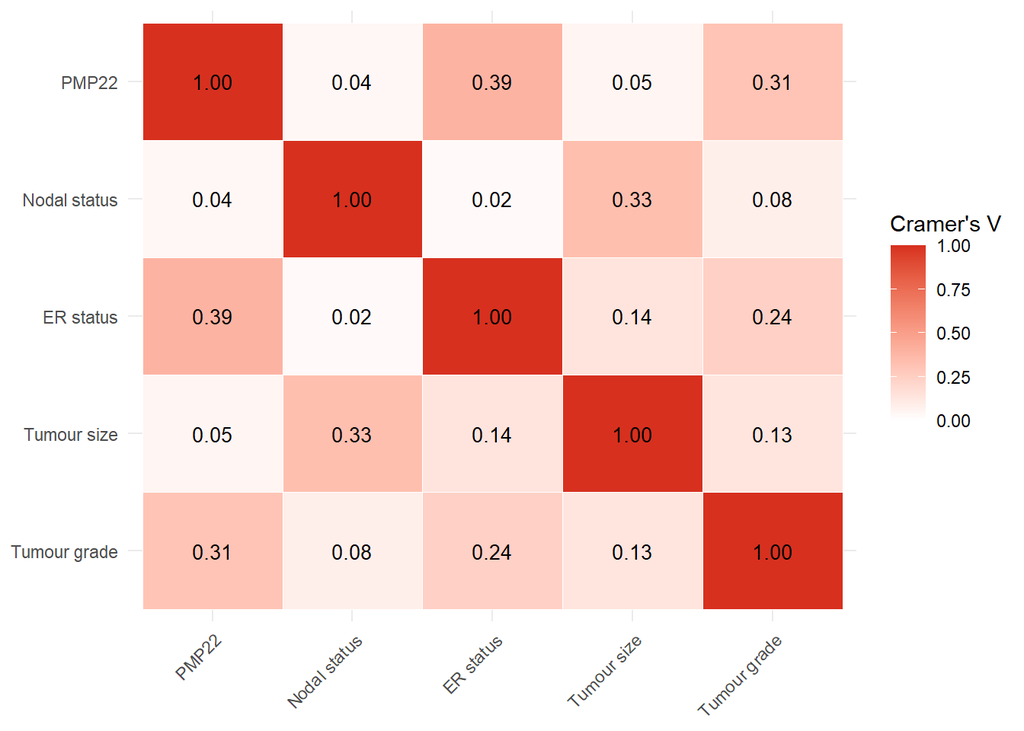

Pairwise association strength (Cramer’s V) among the five predictors, complete cases (n = 208). The diagonal is fixed at 1 by definition.

```r
# predictors (factor versions) and display labels
pred_vars   <- c("PMP22_f", "pN_f", "ER_f", "pT_f", "G_f")
pred_labels <- c(PMP22_f = "PMP22", pN_f = "Nodal status", ER_f = "ER status",
                 pT_f = "Tumour size", G_f = "Tumour grade")

# Cramer's V from a two-way table (Pearson chi-square, no continuity correction)
cramers_v <- function(x, y) {
  tab  <- table(x, y)
  chi2 <- suppressWarnings(chisq.test(tab, correct = FALSE)$statistic)
  unname(sqrt(chi2 / (sum(tab) * (min(dim(tab)) - 1))))
}

assoc_mat <- matrix(1, nrow = length(pred_vars), ncol = length(pred_vars),
                    dimnames = list(pred_labels[pred_vars], pred_labels[pred_vars]))

for (p in combn(pred_vars, 2, simplify = FALSE)) {
  v <- cramers_v(pmpdata_complete[[p[1]]], pmpdata_complete[[p[2]]])
  assoc_mat[pred_labels[p[1]], pred_labels[p[2]]] <- v
  assoc_mat[pred_labels[p[2]], pred_labels[p[1]]] <- v
}

assoc_df <- as.data.frame(as.table(assoc_mat))
names(assoc_df) <- c("Var1", "Var2", "CramersV")
# keep the predictor order on both axes
assoc_df$Var1 <- factor(assoc_df$Var1, levels = pred_labels)
assoc_df$Var2 <- factor(assoc_df$Var2, levels = rev(pred_labels))

ggplot(assoc_df, aes(Var1, Var2, fill = CramersV)) +
  geom_tile(color = "white") +
  geom_text(aes(label = sprintf("%.2f", CramersV)), size = 3.5) +
  scale_fill_gradient(low = "white", high = "#D7301F", limits = c(0, 1),
                      name = "Cramer's V") +
  labs(x = NULL, y = NULL) +
  theme_minimal(base_size = 11) +
  theme(axis.text.x = element_text(angle = 45, hjust = 1))
```

The heatmap shows that the strongest pair-wise association is between PMP22 and ER.

## 1.5 Outcome summary

Among 208 patients, 93 events occurred (44.7%).

```r
pmpdata_complete %>%
  count(rezs) %>%
  mutate(percent = round(100 * n / sum(n), 2))
```

```
  rezs   n percent
1    0 115   55.29
2    1  93   44.71
```

Follow-up time is summarised using the reverse Kaplan-Meier estimator (i.e., Kaplan-Meier with the event indicator reversed) (Schemper and Smith 1996), which provides an estimate of potential follow-up.

```r
# reverse KM: flip event indicator (Schemper & Smith, 1996)
fit_rkm <- survfit(Surv(days, 1 - rezs) ~ 1, data = pmpdata_complete)

cat("Median follow-up:", summary(fit_rkm)$table["median"],
    "days (~", round(summary(fit_rkm)$table["median"] / 365.25, 1), "years) (95%CI", summary(fit_rkm)$table["0.95LCL"], "-", summary(fit_rkm)$table["0.95UCL"], " days)\n")
```

```
Median follow-up: 3210 days (~ 8.8 years) (95%CI 2939 - 3606  days)
```

Disease-free survival is visualised using an unstratified Kaplan-Meier curve.

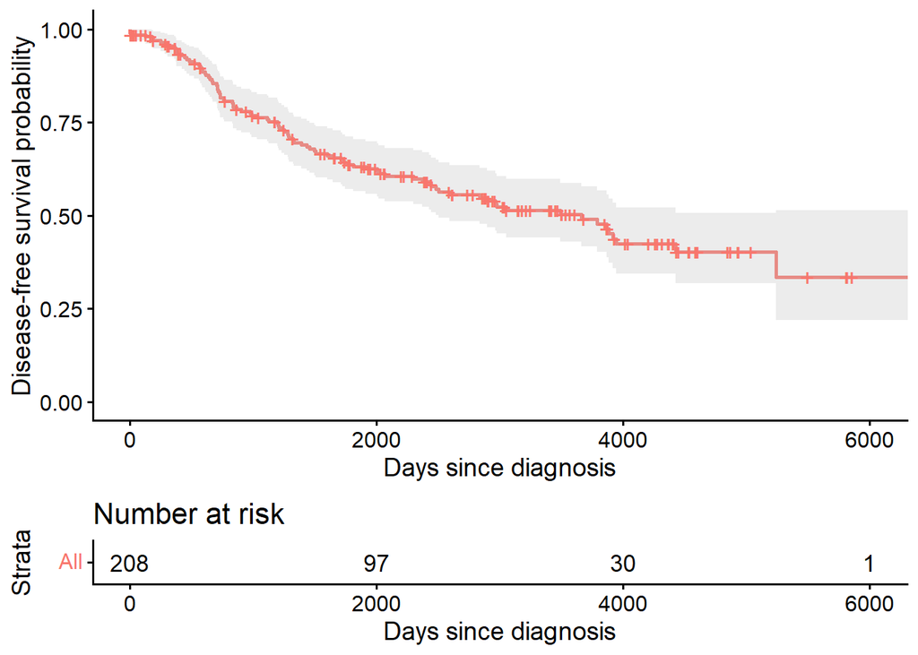

Figure: Kaplan-Meier estimate of disease-free survival.

```r
fit_km <- survfit(Surv(days, rezs) ~ 1, data = pmpdata_complete)

ggsurvplot(fit_km, data = pmpdata_complete, risk.table = TRUE, conf.int = TRUE,
           xlab = "Days since diagnosis", ylab = "Disease-free survival probability",
           legend = "none")
```

## 1.6 Main research question

The objective is to estimate the association between PMP22 and disease-free survival while adjusting for established clinical predictors. A multivariable Cox model is specified a priori. No data-driven variable selection is applied.

**Additional information: model considerations**

In applied analyses, key assumptions of the Cox model should be assessed, including proportional hazards and potential multicollinearity. Pre-specified interactions may be considered where clinically justified. If the proportional hazards assumption is violated (e.g., for variable `ER`), time-varying effects can be incorporated, for example, by modelling an interaction of `ER` with log(`days`).

The pre-specified model is:

```r
full_mod <- coxph(Surv(days, rezs) ~ PMP22 + pT + pN + G + ER, data = pmpdata_complete,
                  x = TRUE, y = TRUE)

summary(full_mod)
```

```
Call:
coxph(formula = Surv(days, rezs) ~ PMP22 + pT + pN + G + ER,
    data = pmpdata_complete, x = TRUE, y = TRUE)

  n= 208, number of events= 93

          coef exp(coef) se(coef)      z Pr(>|z|)
PMP22  0.57211   1.77200  0.24586  2.327  0.01997 *
pT     0.23985   1.27106  0.16093  1.490  0.13612
pN     1.00127   2.72175  0.24339  4.114 3.89e-05 ***
G     -0.01906   0.98112  0.17368 -0.110  0.91263
ER    -0.72083   0.48635  0.23800 -3.029  0.00246 **
---
Signif. codes:  0 '***' 0.001 '**' 0.01 '*' 0.05 '.' 0.1 ' ' 1

      exp(coef) exp(-coef) lower .95 upper .95
PMP22    1.7720     0.5643    1.0944    2.8691
pT       1.2711     0.7867    0.9272    1.7424
pN       2.7217     0.3674    1.6892    4.3855
G        0.9811     1.0192    0.6981    1.3790
ER       0.4863     2.0561    0.3050    0.7754

Concordance= 0.683  (se = 0.027 )
Likelihood ratio test= 30.66  on 5 df,   p=1e-05
Wald test            = 27.08  on 5 df,   p=6e-05
Score (logrank) test = 28.6  on 5 df,   p=3e-05
```

A typical tabular presentation in a publication could have the following form:

```r
full_mod_tab <- extract_cox(full_mod) %>%
  transmute(
    Variable = c("PMP22", "Tumour Size (pT)", "Nodal Status (pN)", "Tumour Grade (G)", "ER Status (ER)"),
    `Hazard ratio` = round(HR, 2),
    `95% CI`       = paste0("(", round(CI_low, 2), ", ", round(CI_high, 2), ")"),
    `p-value`      = format.pval(p, digits = 3, eps = 0.001)
  )

kable(full_mod_tab,
      row.names = FALSE,
      col.names = c("Variable", "HR", "95% CI", "p-value")) %>%
  add_header_above(c(" " = 1, "Multivariable model" = 3)) %>%
  kable_styling(full_width = TRUE, position = "center") %>%
  column_spec(1:4, width = "25%") %>%
  row_spec(0, bold = TRUE) %>%
  row_spec(seq(1, nrow(full_mod_tab), by = 2), background = "#F2F2F2") %>%
  row_spec(1, bold = TRUE)
```

Table: Pre-defined multivariable Cox model for disease-free survival based on 208 observations and 93 events.

| Variable | Multivariable model HR | Multivariable model 95% CI | Multivariable model p-value |
| --- | --- | --- | --- |
| PMP22 | 1.77 | (1.09, 2.87) | 0.020 |
| Tumour Size (pT) | 1.27 | (0.93, 1.74) | 0.136 |
| Nodal Status (pN) | 2.72 | (1.69, 4.39) | <0.001 |
| Tumour Grade (G) | 0.98 | (0.7, 1.38) | 0.913 |
| ER Status (ER) | 0.49 | (0.31, 0.78) | 0.002 |

**The results of the model can be interpreted as:** After adjustment for known clinical predictors (tumour size, tumour grade, ER status, and nodal status), higher PMP22 expression is associated with an increased hazard of recurrence (HR 1.77, 95% CI 1.09 to 2.87; p = 0.020).

(In the original publication (Tong et al. 2010), this model is summarized on the right side of Table 3).

# 2 Analysis using univariable selection

*This workflow reflects a common but problematic practice: each predictor is tested separately, and only statistically significant variables are retained for a final multivariable model.*

## 2.1 Univariable screening

Each model is fitted on the subset of data available for that predictor. Consequently, sample size and number of events can vary across models. This is often not reported.

```r
vars <- c("PMP22", "pT", "pN", "G", "ER")

# fit one univariable Cox model per candidate predictor, each using whatever
# observations happen to be non-missing for that single variable
uni_fits <- lapply(vars, function(v) {
  coxph(as.formula(paste0("Surv(days, rezs) ~ ", v)), data = pmpdata, na.action = na.omit)
})
names(uni_fits) <- vars

uni_tab <- do.call(rbind, lapply(uni_fits, extract_cox))

uni_display <- uni_tab %>%
  transmute(
    Variable = variable,
    n = n,
    Events = events,
    HR = round(HR, 2),
    `p-value` = format.pval(p, digits = 3, eps = 0.001)
  )

uni_display <- uni_tab %>%
  transmute(
    Variable = factor(variable, levels = vars),
    `n (events)` = paste0(n, " (", events, ")"),
    HR = round(HR, 2),
    `95% CI` = paste0("(", round(CI_low, 2), ", ", round(CI_high, 2), ")"),
    `p-value` = format.pval(p, digits = 3, eps = 0.001)
  ) %>%
  arrange(Variable)

kable(uni_display,
      row.names = FALSE,
      col.names = c("Variable", "n (events)", "HR", "95% CI", "p-value")) %>%
  add_header_above(c(" " = 1, "Univariable models" = 4)) %>%
  kable_styling(full_width = TRUE, position = "center") %>%
  column_spec(1, width = "25%") %>%
  column_spec(2:5, width = "18.75%") %>%
  row_spec(0, bold = TRUE) %>%
  row_spec(1, bold = TRUE) %>%
  row_spec(seq(1, nrow(uni_display), by = 2), background = "#F2F2F2")
```

Table: Five univariable Cox regression models, each with its own available observations and events.

| Variable | Univariable models n (events) | Univariable models HR | Univariable models 95% CI | Univariable models p-value |
| --- | --- | --- | --- | --- |
| PMP22 | 247 (109) | 1.01 | (0.69, 1.46) | 0.978 |
| pT | 230 (100) | 1.32 | (0.99, 1.78) | 0.061 |
| pN | 219 (96) | 2.72 | (1.73, 4.27) | <0.001 |
| G | 227 (103) | 1.06 | (0.78, 1.44) | 0.702 |
| ER | 247 (109) | 0.63 | (0.43, 0.92) | 0.017 |

Variables with p < 0.05 are retained:

```r
alpha_screen <- 0.05

selected <- uni_tab$variable[uni_tab$p < alpha_screen]
dropped <- setdiff(vars, selected)

cat("Retained after univariable screen (p <", alpha_screen, "):",
    paste(selected, collapse = ", "), "\n\n")
```

```
Retained after univariable screen (p < 0.05 ): pN, ER
```

```r
cat("Dropped:",
    paste(dropped, collapse = ", "), "\n")
```

```
Dropped: PMP22, pT, G
```

Only nodal status (`pN`) and estrogen receptor status (`ER`) are selected by univariable screening. **PMP22, the variable of primary interest, is excluded.** This occurs because univariable associations do not account for confounding. The effect of PMP22 (`PMP22`) is masked by its correlation with ER status (`ER`), which becomes apparent only after adjustment.

## 2.2 Multivariable model based on univariably selected variables

A multivariable model is fitted using only the selected predictors.

```r
fit_uni_full <- coxph(as.formula(paste("Surv(days, rezs) ~", paste(selected, collapse = " + "))), data = pmpdata)

cat("Complete-case n for the reduced model:", fit_uni_full$n, "\n\n")
```

```
Complete-case n for the reduced model: 218
```

The sample size of this multivariable model differs from the screening models due to joint missingness across selected variables.

```r
summary(fit_uni_full)
```

```
Call:
coxph(formula = as.formula(paste("Surv(days, rezs) ~", paste(selected,
    collapse = " + "))), data = pmpdata)

  n= 218, number of events= 96
   (30 Beobachtungen als fehlend gelöscht)

      coef exp(coef) se(coef)      z Pr(>|z|)
pN  1.0154    2.7606   0.2304  4.408 1.05e-05 ***
ER -0.4714    0.6241   0.2057 -2.292   0.0219 *
---
Signif. codes:  0 '***' 0.001 '**' 0.01 '*' 0.05 '.' 0.1 ' ' 1

   exp(coef) exp(-coef) lower .95 upper .95
pN    2.7606     0.3622     1.757    4.3361
ER    0.6241     1.6022     0.417    0.9341

Concordance= 0.682  (se = 0.026 )
Likelihood ratio test= 26.29  on 2 df,   p=2e-06
Wald test            = 23.92  on 2 df,   p=6e-06
Score (logrank) test = 25.55  on 2 df,   p=3e-06
```

Based on this approach, PMP22 would not be considered prognostically relevant.

A tabular presentation in a publication could have the following form. (In practice, the sample sizes and number of events used in the different models are typically not shown.)

```r
multi_sel_tab <- extract_cox(fit_uni_full)

# prepare univariable table
uni_fmt <- uni_tab %>%
  transmute(
    Variable = variable,
    `n (events)_uni` = paste0(n, " (", events, ")"),
    HR_uni = round(HR, 2),
    CI_uni = paste0("(", round(CI_low, 2), ", ", round(CI_high, 2), ")"),
    p_uni = format.pval(p, digits = 3, eps = 0.001)
  )

# prepare multivariable (selected) table
multi_fmt <- multi_sel_tab %>%
  transmute(
    Variable = variable,
    `n (events)_multi` = paste0(n, " (", events, ")"),
    HR_multi = round(HR, 2),
    CI_multi = paste0("(", round(CI_low, 2), ", ", round(CI_high, 2), ")"),
    p_multi = format.pval(p, digits = 3, eps = 0.001)
  )

# merge side-by-side
uni_multi_tab <- merge(uni_fmt, multi_fmt, by = "Variable", all = TRUE) %>%
  arrange(match(Variable, uni_fmt$Variable))

uni_multi_tab[is.na(uni_multi_tab)] <- ""

kable(uni_multi_tab, row.names = FALSE,
      col.names = c("Variable",
                    "n (events)", "HR", "95% CI", "p-value",
                    "n (events)", "HR", "95% CI", "p-value")) %>%
  add_header_above(c(" " = 1,
                     "Univariable models" = 4,
                     "Multivariable model (selected)" = 4)) %>%
  row_spec(1, bold = TRUE)
```

Table: Univariable Cox regression results and multivariable model derived by univariable screening.

| Variable | Univariable models n (events) | Univariable models HR | Univariable models 95% CI | Univariable models p-value | Multivariable model (selected) n (events) | Multivariable model (selected) HR | Multivariable model (selected) 95% CI | Multivariable model (selected) p-value |
| --- | --- | --- | --- | --- | --- | --- | --- | --- |
| PMP22 | 247 (109) | 1.01 | (0.69, 1.46) | 0.978 |  |  |  |  |
| pT | 230 (100) | 1.32 | (0.99, 1.78) | 0.061 |  |  |  |  |
| pN | 219 (96) | 2.72 | (1.73, 4.27) | <0.001 | 218 (96) | 2.76 | (1.76, 4.34) | <0.001 |
| G | 227 (103) | 1.06 | (0.78, 1.44) | 0.702 |  |  |  |  |
| ER | 247 (109) | 0.63 | (0.43, 0.92) | 0.017 | 218 (96) | 0.62 | (0.42, 0.93) | 0.022 |

**Additional information: interpretation after selection**

Estimates from a model derived via variable selection are typically reported as if the selected variables had been pre-specified. However, standard errors, confidence intervals, and p-values do not account for the selection process and are therefore biased, i.e., typically they are too optimistic. In practice, this limitation is often not acknowledged and the application of univariable screening is sometimes not reported.

# 3 Contrasting the two approaches

```r
full_tab <- extract_cox(full_mod)

# merge univariable and full-model results by predictor name
merged <- merge(uni_tab, full_tab, by = "variable",
                suffixes = c("_uni", "_full"), all = TRUE)

# --- formatting ---
final_out <- merged %>%
  transmute(
    Variable = factor(variable, levels = vars),

#    n_uni = n_uni,
    `n (events)_uni` = paste0(n_uni, " (", events_uni, ")"),
    HR_uni = round(HR_uni, 2),
    CI_uni = paste0("(", round(CI_low_uni, 2), ", ", round(CI_high_uni, 2), ")"),
    p_uni = format.pval(p_uni, digits = 3, eps = 0.001),

#    n_full = n_full,
    `n (events)_full` = paste0(n_full, " (", events_full, ")"),
    HR_full = round(HR_full, 2),
    CI_full = paste0("(", round(CI_low_full, 2), ", ", round(CI_high_full, 2), ")"),
    p_full = format.pval(p_full, digits = 3, eps = 0.001)
  ) %>%
  arrange(Variable)

kable(final_out,
      col.names = c(
        "Variable", rep(c("n (events)", "HR", "95% CI", "p-value"), times = 2))) %>%
  add_header_above(c(" " = 1, "Univariable" = 4, "Full model" = 4)) %>%
  row_spec(1, bold = TRUE)
```

Table: Univariable versus multivariable Cox regression results.

| Variable | Univariable n (events) | Univariable HR | Univariable 95% CI | Univariable p-value | Full model n (events) | Full model HR | Full model 95% CI | Full model p-value |
| --- | --- | --- | --- | --- | --- | --- | --- | --- |
| PMP22 | 247 (109) | 1.01 | (0.69, 1.46) | 0.978 | 208 (93) | 1.77 | (1.09, 2.87) | 0.020 |
| pT | 230 (100) | 1.32 | (0.99, 1.78) | 0.061 | 208 (93) | 1.27 | (0.93, 1.74) | 0.136 |
| pN | 219 (96) | 2.72 | (1.73, 4.27) | <0.001 | 208 (93) | 2.72 | (1.69, 4.39) | <0.001 |
| G | 227 (103) | 1.06 | (0.78, 1.44) | 0.702 | 208 (93) | 0.98 | (0.7, 1.38) | 0.913 |
| ER | 247 (109) | 0.63 | (0.43, 0.92) | 0.017 | 208 (93) | 0.49 | (0.31, 0.78) | 0.002 |

**The two analytical strategies lead to different conclusions. A pre-specified multivariable model identifies PMP22 as prognostically relevant, whereas univariable screening excludes it.**

This discrepancy arises because univariable screening ignores joint effects and dependencies between predictors.

**Key message**

Univariable selection can lead to exclusion of clinically relevant variables and biased inference. Pre-specification of multivariable models, guided by subject-matter knowledge, avoids these issues and yields more interpretable results.

# 4 References

Heinze, Georg, and Dan Tong. 2026. “Gene Expression of PMP22 and Recurrence-Free Survival After Breast Cancer.” Zenodo. https://doi.org/10.5281/zenodo.19632792.

Schemper, Michael, and Terry L. Smith. 1996. “A Note on Quantifying Follow-up in Studies of Failure Time.” *Controlled Clinical Trials* 17: 343–46. https://doi.org/10.1016/0197-2456(96)00075-x.

Tong, Dan, Georg Heinze, Dietmar Pils, Andrea Wolf, Christian F Singer, Nicole Concin, Gerda Hofstetter, Ingrid Schiebel, Margaretha Rudas, and Robert Zeillinger. 2010. “Gene Expression of PMP22 Is an Independent Prognostic Factor for Disease-Free and Overall Survival in Breast Cancer Patients.” *BMC Cancer* 10 (1): 682. https://doi.org/10.1186/1471-2407-10-682.

Ullmann, Theresa, Georg Heinze, Franziska Kappenberg, Marc Henrion, Willi Sauerbrei, Gary Collins, Carl-Stephan Leonhardt, Mariana Nold, Daniela Dunkler, and for TG2 of the STRATOS initiative. 2026. “The Problem with Univariable Selection in Regression Modelling-and What to Do Instead.” *In Preparation*.

# 5 Computing Environment

**Use of AI:** AI tools were used to assist in formulating the text and implementing the analyses. The authors critically reviewed, revised, and adapted AI-generated content and code.